# Sample Application of the Robust EZBHDDM: A Lexical Decision Task study

```r
library(rmdformats)
library(R2jags)
library(here)

# Set seed for reproducibility
seed <- 43
```

# Introduction: Study description

We present a sample application of our Robust implementation of the Hierarchical Bayesian EZ Drift-Diffusion Model (EZHBDM) to open data from the MEGALEX megastudy ([Ferrand et al, 2018](https://doi.org/10.3758/s13428-017-0943-1))

In this study, the authors looked at word recognition performance in a lexical decision task (LDT) where participants had to decide whether a presented stimulus was a *real word* or a *pseudoword* (non-word). The authors compared performance across visual and auditory modalities in a **between-subjects design.**

- **Visual modality**: 96 participants responded to **28,466 French words** and an equal number of pseudowords, presented as text on a computer screen. Participants completed 109 blocks of 260 trials each.
- **Auditory modality**: 101 participants responded to **17,876 French words** and matched pseudowords, presented as synthesized speech with a female French voice. Participants completed 100 blocks of 177 trials each.

### Data used

In this demo, we **only consider the first 20 blocks and 30 participants for each modality**. This is done with the purpose of simplifying the data cleaning process, given that the original data contains several instances of incomplete or miscoded data.

```r
nP <- 30
nB <- 20
```

# Loading and Cleaning the Data

The MEGALEX data is available at [lexique.org](http://www.lexique.org/?page_id=366). We worked with the `Megalex raw data.zip` (75 MB) file, from which we extracted two main files: `megalex_rawdata_auditory.csv` and `megalex_rawdata_visual.csv`.

```r
data_folder <- here("demos", "applications", "lexical-task", "data")

# Load the raw AUDITORY data
data_auditory <- read.csv(file.path(data_folder, "megalex_rawdata_auditory.csv"), sep = "\t")

# Only first nP participants for each modality
aud_sub <- unique(data_auditory$SUBJECT)[1:nP]
data_auditory <- data_auditory[data_auditory$SUBJECT %in% aud_sub, ]
# Only first nB blocks for each participant
data_auditory <- data_auditory[data_auditory$BLOCK <= nB, ]

# Load the raw VISUAL data
data_visual <- read.csv(file.path(data_folder, "megalex_rawdata_visual.csv"), sep = "\t")
# Only first nP participants for each modality
vis_sub <- unique(data_visual$SUBJECT)[1:nP]
data_visual <- data_visual[data_visual$SUBJECT %in% vis_sub, ]
# Only first nB blocks for each participant
data_visual <- data_visual[data_visual$BLOCK <= nB, ]
```

For simplicity, we **combine the two datasets into a single data frame** containing the accuracy and response time data, along with relevant ID information such as the subject ID, the block number, the stimulus category (word or pseudoword), and the modality (visual or auditory).

```r
# First, we recode the subject ID of the auditory dataset
# since both data files use the same subject ID scheme,
# despite the between-subjects design.
data_auditory$SUBJECT <- as.numeric(data_auditory$SUBJECT) + 1000

# Next, we isolate relevant existing columns
keep_columns <- c("SUBJECT", "BLOCK", "CORRECT", "RT")
data_visual <- data_visual[,keep_columns]
data_auditory <- data_auditory[,keep_columns]
# And add a modality column
data_visual$MODALITY <- 1
data_auditory$MODALITY <- 2

# Finally, we combine the datasets
raw_data <- rbind(data_auditory, data_visual)
```

This leads to a total of 262200 trials, with 60 participants split evenly across the two modalities:

```r
# Participants per modality
tapply(raw_data$SUBJECT, raw_data$MODALITY, function(x) length(unique(x)))
```

```
##  1  2
## 30 30
```

Furthermore, we confirmed that each participant completed the same number of trials in each block as expected for each of the two modalities.

```r
# Check trials per cell
check_cells <- aggregate(RT ~ SUBJECT + BLOCK, data = raw_data, length)
table(check_cells[,3])
```

```
##
## 177 260
## 600 600
```

### Data Cleaning

**Remove extreme RT trials**

In the MEGALEX study, the authors identified trials with a response time less than 300ms or greater than 2000ms as outliers and removed them from the analysis.

```r
data_clean <- raw_data[raw_data$RT >= 300 & raw_data$RT <= 2000,]
```

By replicating this cleaning step, we remove a total of 2053 trials.

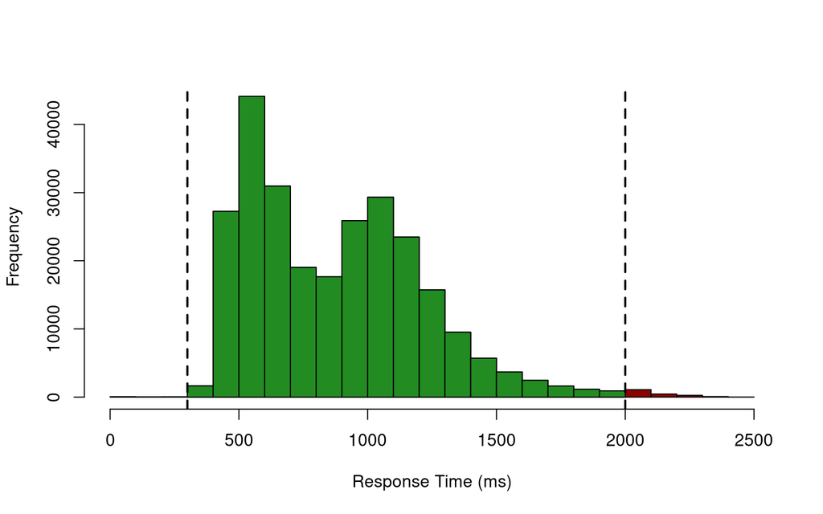

```r
hist(raw_data$RT, col="darkred", main="", xlab="Response Time (ms)")
hist(data_clean$RT, add = TRUE, col = "forestgreen")
abline(v = c(300, 2000), lty = 2, lwd = 2, col = "black")
```

# Get Summary Statistics

We now compute both standard and robust summary statistics for every participant across the auditory and visual modalities. To make this endeavor easier, we define a custom function.

```r
get_ez_summaries <- function(subset) {
    # Convert RT from milliseconds to seconds
    RT_sec <- subset$RT / 1000
    return(data.frame(
        subject   = unique(subset$SUBJECT),
        block     = unique(subset$BLOCK),
        modality  = unique(subset$MODALITY),
        nTrials   = nrow(subset),
        nCorrect  = sum(subset$CORRECT),
        accRate   = mean(subset$CORRECT),
        meanRT    = mean(RT_sec),
        varRT     = var(RT_sec),
        medianRT  = median(RT_sec),
        varRT_iqr = (IQR(RT_sec) / 1.35)^2
    ))
}
```

### Compute summary statistics from data

We compute summary statistics **per participant per block**.

```r
# Get unique participant-block combinations (same across raw and clean)
unique_cells <- unique(raw_data[, c("SUBJECT", "BLOCK")])

# Initialize empty data frames
summaries_raw   <- data.frame()
summaries_clean <- data.frame()

# Compute summaries for each participant-block cell
for (i in 1:nrow(unique_cells)) {
    subj  <- unique_cells$SUBJECT[i]
    block <- unique_cells$BLOCK[i]

    # Raw data
    cell_raw <- raw_data[raw_data$SUBJECT == subj & raw_data$BLOCK == block, ]
    if (nrow(cell_raw) >= 10) {
        summ <- get_ez_summaries(cell_raw)
        summaries_raw <- rbind(summaries_raw, summ)
    }

    # Clean data
    cell_clean <- data_clean[data_clean$SUBJECT == subj & data_clean$BLOCK == block, ]
    if (nrow(cell_clean) >= 10) {
        summ <- get_ez_summaries(cell_clean)
        summaries_clean <- rbind(summaries_clean, summ)
    }
}
```

# The Model

## The EZ Hierarchical Bayesian DDM (EZHBDDM)

The first component of our model is the “proxy” model that we introduced in previous work (Chávez De la Peña & Vandekerckhove, 2025) allowing for the Bayesian implementation of the EZ-DDM: a reformulation of the three-parameter DDM that uses the method of moments to map summary statistics of the observed data to theoretical moments expressed as functions of the model parameters: drift rate $\nu$, boundary separation $\alpha$, and non-decision time $\tau$.

$$\begin{align*}
PC &= \frac{1}{\exp(-\alpha\nu)+1}\\
MRT &= \tau + \frac{\alpha}{2\nu}\frac{\exp(-\alpha\nu)-1}{\exp(-\alpha\nu)+1}\\
PRT &= \frac{\alpha}{2\nu^3}\left\{\frac{1-2\alpha\nu\exp(-\alpha\nu)-\exp(-\alpha\nu)^2}{(\exp(-\alpha\nu)+1)^2}\right\}
\end{align*}$$

Our proxy model uses the sampling distributions for these three summary statistics (the number of correct responses $\dot{T}$, a measure of central tendency $\dot{M}$ and dispersion $\dot{V}$ of the response times) to facilitate a generative model.

$$\begin{align*}
\dot{T} &\sim \text{Binomial}(PC, N)\\
\dot{V} &\sim \text{Normal}\left(\frac{1}{PRT}, \frac{N-1}{2(PRT)^2}\right)\\
\dot{M} &\sim \text{Normal}(MRT, PRT \times N)
\end{align*}$$

## The Robust Extension

The **standard EZHBDDM** uses the sample mean and variance of RT as the summary statistics $\dot{M}$ and $\dot{V}$. These estimators are sensitive to outliers, which are common in response time data.

The **robust EZHBDDM** replaces these with more robust estimators: the median RT (replacing the mean RT) and the IQR-derived variance (replacing the sample variance).

The same JAGS model can be used for both approaches; the only difference is which summary statistics we pass to the model.

## Metaregression Structure

We incorporate the following effects:

- **Modality effect on drift rate** ($\beta_0$): Captures the difference in drift rate between visual and auditory modalities.
- **Modality and block effects on boundary separation** ($\beta_1$, $\beta_2$): Captures the difference in boundary separation between visual and auditory modalities, as well as the difference in boundary separation across blocks.
- **Modality effect on non-decision time** ($\beta_3$): Captures the difference in non-decision time between visual and auditory modalities.

$$\begin{align*}
\nu^{\text{pred}}_j &= \mu_\nu + \beta_0 X_j, \quad\quad\quad j = 1,2\\
\tau^{\text{pred}}_j &= \mu_\tau + \beta_3 X_j\\
\alpha^{\text{pred}}_{b,j} &= \mu_\alpha + \beta_1 X_j + \beta_2 Y_b,\quad\quad b = 1,\ldots,B, j = 1,2\\
\nu_i &\sim \mbox{Normal}(\nu^{\text{pred}}_{\text{mod}[i]}, \sigma_\nu)\\
\tau_i &\sim \mbox{Normal}(\tau^{\text{pred}}_{\text{mod}[i]}, \sigma_\tau)\\
\alpha_i &\sim \mbox{Normal}(\alpha^{\text{pred}}_{\text{block}[i],\,\text{mod}[i]}, \sigma_\alpha)
\end{align*}$$

where $X_j$ is the modality contrast: $X_1 = 0.5$ (visual), $X_2 = -0.5$ (auditory), and $Y_b$ is the block number: $Y_b = b$ for $b = 1,\ldots,B$

### Write the Model in JAGS

```r
modelFile <- here("output", "BUGS-models", "demo_lexical_model.bug")

write("
model {
    # Wide Priors for hierarchical DDM parameters
    bound_mean ~ dnorm(0.12, pow(0.10, -2)) T(0.01, )
    drift_mean ~ dnorm(2.00, pow(2.00, -2))
    nondt_mean ~ dnorm(0.30, pow(0.15, -2)) T(0.05, )
    bound_sdev ~ dunif(0.01, 0.50)
    drift_sdev ~ dunif(0.10, 5.00)
    nondt_sdev ~ dunif(0.01, 0.50)

    # Wide Priors for Regression coefficients
    beta0 ~ dnorm(0.00, pow(2.00, -2))   # Modality effect on drift
    beta1 ~ dnorm(0.00, pow(0.10, -2))   # Modality effect on boundary
    beta2 ~ dnorm(0.00, pow(0.05, -2))   # Block effect on boundary
    beta3 ~ dnorm(0.00, pow(0.10, -2))   # Modality effect on non-decision time

    # Predicted means for each parameter
    for (j in 1:2) {
        drift_pred[j] = drift_mean + beta0 * X[j]
        nondt_pred[j] = nondt_mean + beta3 * X[j]
        for (b in 1:nBlocks) {
            bound_pred[b, j] = bound_mean + beta1 * X[j] + beta2 * Y[b]
        }
    }

    # Person-by-block sampling model
    for (i in 1:N) {
        drift[i] ~ dnorm(drift_pred[mod[i]], pow(drift_sdev, -2))
        bound[i] ~ dnorm(bound_pred[block[i], mod[i]], pow(bound_sdev, -2)) T(0.01, )
        nondt[i] ~ dnorm(nondt_pred[mod[i]], pow(nondt_sdev, -2)) T(0.05, )

        # Forward EZ-DDM equations
        ey[i] = exp(-bound[i] * drift[i])
        Pc[i] = 1 / (1 + ey[i])
        PRT[i] = 2 * pow(drift[i], 3) / bound[i] *
                 pow(ey[i] + 1, 2) / (2 * -bound[i] *
                 drift[i] * ey[i] - ey[i] * ey[i] + 1)
        MDT[i] = (bound[i] / (2 * drift[i])) * (1 - ey[i]) / (1 + ey[i])
        MRT[i] = MDT[i] + nondt[i]

        # Sampling distributions
        nCorrect[i] ~ dbin(Pc[i], nTrials[i])
        vRT[i] ~ dnorm(1/PRT[i], 0.5 * (nTrials[i] - 1) * PRT[i] * PRT[i])
        mRT[i] ~ dnorm(MRT[i], PRT[i] * nTrials[i])
    }
}", modelFile)
```

**Note:** This model uses `mRT` and `vRT` as placeholders for the observed RT statistics. To fit the standard model, we will pass mean and variance; to fit the robust model, we will pass median and IQR-derived variance.

# JAGS

### Specify JAGS setup

```r
# JAGS setup
n.chains  <- 4
n.iter    <- 2000
n.burnin  <- 500
n.thin    <- 1

# Parameters to track
parameters <- c('beta0', 'beta1', 'beta2', 'beta3',
                'drift_mean', 'bound_mean', 'nondt_mean',
                'drift', 'drift_pred',
                'bound', 'bound_pred',
                'nondt', 'nondt_pred')
```

### Prepare data to pass to JAGS

We prepare four data lists to compare Standard vs Robust EZ-DDM across Raw vs Clean data.

```r
X <- c(0.5, -0.5)
Y <- unique(c(summaries_raw$block, summaries_clean$block))

# Base data lists (standard uses mean/var)
raw_standard <- list(
    N        = nrow(summaries_raw),
    nBlocks  = nB,
    nTrials  = summaries_raw$nTrials,
    nCorrect = summaries_raw$nCorrect,
    mRT      = summaries_raw$meanRT,
    vRT      = summaries_raw$varRT,
    mod      = summaries_raw$modality,
    block    = summaries_raw$block,
    X        = X,
    Y        = Y
)

clean_standard <- list(
    N        = nrow(summaries_clean),
    nBlocks  = nB,
    nTrials  = summaries_clean$nTrials,
    nCorrect = summaries_clean$nCorrect,
    mRT      = summaries_clean$meanRT,
    vRT      = summaries_clean$varRT,
    mod      = summaries_clean$modality,
    block    = summaries_clean$block,
    X        = X,
    Y        = Y
)

# Robust versions (swap mRT and vRT)
raw_robust <- raw_standard
raw_robust$mRT <- summaries_raw$medianRT
raw_robust$vRT <- summaries_raw$varRT_iqr

clean_robust <- clean_standard
clean_robust$mRT <- summaries_clean$medianRT
clean_robust$vRT <- summaries_clean$varRT_iqr

# Combine into list of lists
jags_data_list <- list(
    standard_raw   = raw_standard,
    standard_clean = clean_standard,
    robust_raw     = raw_robust,
    robust_clean   = clean_robust
)

condition_names <- names(jags_data_list)
```

```r
condition_names <- c("standard_raw", "standard_clean", "robust_raw", "robust_clean")
```

### Run JAGS

**Note:** If you previously fitted an older version of this model, delete the existing `samples_*.RData` files in this folder before knitting so JAGS re-fits.

```r
set.seed(seed)
save_folder <- here("demos", "applications", "lexical-task")

# Check if all .RData files exist
files_exist <- sapply(condition_names, function(nm) {
    file.exists(file.path(save_folder, paste0("samples_", nm, ".RData")))
})

# Run JAGS only if at least one file is missing
if (!all(files_exist)) {
    for (cond in condition_names) {
        rdata_file <- file.path(save_folder, paste0("samples_", cond, ".RData"))

        if (!file.exists(rdata_file)) {
            samples <- jags(
                data = jags_data_list[[cond]],
                parameters.to.save = parameters,
                model.file = modelFile,
                n.chains = n.chains,
                n.iter = n.iter,
                n.burnin = n.burnin,
                n.thin = n.thin,
                DIC = TRUE
            )
            assign(paste0("samples_", cond), samples)
            save(list = paste0("samples_", cond), file = rdata_file)
        }
    }
}

# Load all files
for (cond in condition_names) {
    rdata_file <- file.path(save_folder, paste0("samples_", cond, ".RData"))
    load(rdata_file)
}
```

# Convergence Diagnostics

```r
getRhat <- function(posterior_chains, n.chains = NA) {
    if (is.vector(posterior_chains)) {
        if (is.na(n.chains)) {
            stop("Please specify the number of chains")
        }
        n.iter <- length(posterior_chains) / n.chains
        posterior_chains <- matrix(posterior_chains, ncol = n.chains,
                                   nrow = n.iter, byrow = FALSE)
    }
    n.iter <- nrow(posterior_chains)
    n.chains <- ncol(posterior_chains)

    chainMean <- apply(posterior_chains, 2, mean)
    overall_mean <- mean(chainMean)
    B <- n.iter * var(chainMean)
    chainVar <- apply(posterior_chains, 2, var)
    W <- mean(chainVar)
    Z <- ((n.iter - 1) / n.iter) * W + (1 / n.iter) * B
    Rhat <- sqrt(Z / W)
    return(Rhat)
}
```

```r
# Check convergence for all models
check_convergence <- function(samples, name) {
    rhats <- apply(samples$BUGSoutput$sims.array, 3, getRhat)
    cat(name, "- Max Rhat:", round(max(rhats), 3),
        "| Params with Rhat > 1.05:", sum(rhats > 1.05), "\n")
}

check_convergence(samples_standard_raw, "Standard + Raw")
```

```
## Standard + Raw - Max Rhat: 1.011 | Params with Rhat > 1.05: 0
```

```r
check_convergence(samples_standard_clean, "Standard + Clean")
```

```
## Standard + Clean - Max Rhat: 1.01 | Params with Rhat > 1.05: 0
```

```r
check_convergence(samples_robust_raw, "Robust + Raw")
```

```
## Robust + Raw - Max Rhat: 1.011 | Params with Rhat > 1.05: 0
```

```r
check_convergence(samples_robust_clean, "Robust + Clean")
```

```
## Robust + Clean - Max Rhat: 1.015 | Params with Rhat > 1.05: 0
```

# Results: Comparing Standard vs Robust EZ-DDM

The key demonstration is that the **Robust EZ-DDM** produces similar estimates whether we use raw or cleaned data, while the **Standard EZ-DDM** shows larger differences between raw and clean.

## Extract Key Parameters

```r
# Extract beta0 (modality effect on drift) from all 4 models
beta0_standard_raw   <- as.vector(samples_standard_raw$BUGSoutput$sims.list$beta0)
beta0_standard_clean <- as.vector(samples_standard_clean$BUGSoutput$sims.list$beta0)
beta0_robust_raw     <- as.vector(samples_robust_raw$BUGSoutput$sims.list$beta0)
beta0_robust_clean   <- as.vector(samples_robust_clean$BUGSoutput$sims.list$beta0)

# Extract beta2 (block effect on boundary) from all 4 models
beta2_standard_raw   <- as.vector(samples_standard_raw$BUGSoutput$sims.list$beta2)
beta2_standard_clean <- as.vector(samples_standard_clean$BUGSoutput$sims.list$beta2)
beta2_robust_raw     <- as.vector(samples_robust_raw$BUGSoutput$sims.list$beta2)
beta2_robust_clean   <- as.vector(samples_robust_clean$BUGSoutput$sims.list$beta2)
```

## Modality Effect on Drift Rate ($\beta_0$)

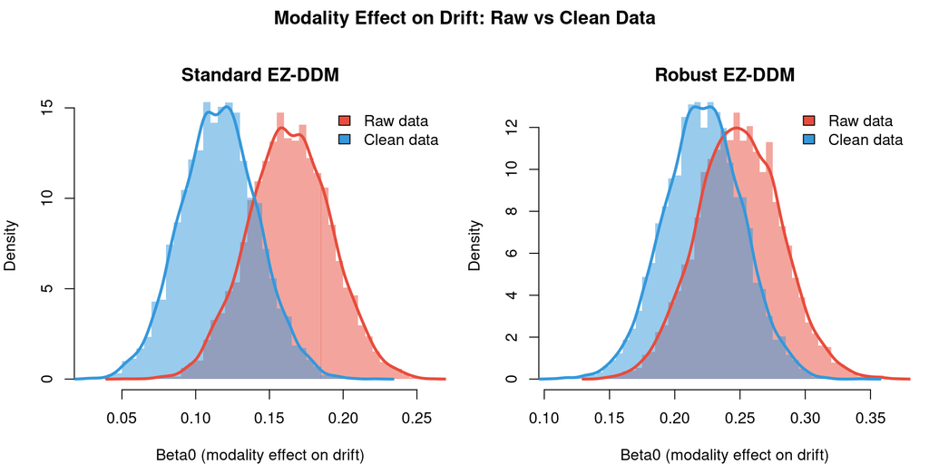

```r
nBreaks <- 40
raw.color <- "#E74C3C"
clean.color <- "#3498DB"

par(mfrow = c(1, 2), mai = c(0.8, 0.8, 0.6, 0.2), oma = c(0, 0, 2.5, 0))

# Standard EZ-DDM
xlim_std <- range(c(beta0_standard_raw, beta0_standard_clean))
hist(beta0_standard_raw, freq = FALSE, breaks = nBreaks, col = adjustcolor(raw.color, 0.5),
     border = NA, main = "Standard EZ-DDM", xlab = "Beta0 (modality effect on drift)",
     xlim = xlim_std)
hist(beta0_standard_clean, freq = FALSE, breaks = nBreaks, col = adjustcolor(clean.color, 0.5),
     border = NA, add = TRUE)
lines(density(beta0_standard_raw), lwd = 3, col = raw.color)
lines(density(beta0_standard_clean), lwd = 3, col = clean.color)
abline(v = 0, lty = 2, col = "gray40")
legend("topright", c("Raw data", "Clean data"), fill = c(raw.color, clean.color), bty = "n")

# Robust EZ-DDM
xlim_rob <- range(c(beta0_robust_raw, beta0_robust_clean))
hist(beta0_robust_raw, freq = FALSE, breaks = nBreaks, col = adjustcolor(raw.color, 0.5),
     border = NA, main = "Robust EZ-DDM", xlab = "Beta0 (modality effect on drift)",
     xlim = xlim_rob)
hist(beta0_robust_clean, freq = FALSE, breaks = nBreaks, col = adjustcolor(clean.color, 0.5),
     border = NA, add = TRUE)
lines(density(beta0_robust_raw), lwd = 3, col = raw.color)
lines(density(beta0_robust_clean), lwd = 3, col = clean.color)
abline(v = 0, lty = 2, col = "gray40")
legend("topright", c("Raw data", "Clean data"), fill = c(raw.color, clean.color), bty = "n")

mtext("Modality Effect on Drift: Raw vs Clean Data", outer = TRUE, line = 1, cex = 1.2, font = 2)
```

## Block Effect on Boundary Separation ($\beta_2$)

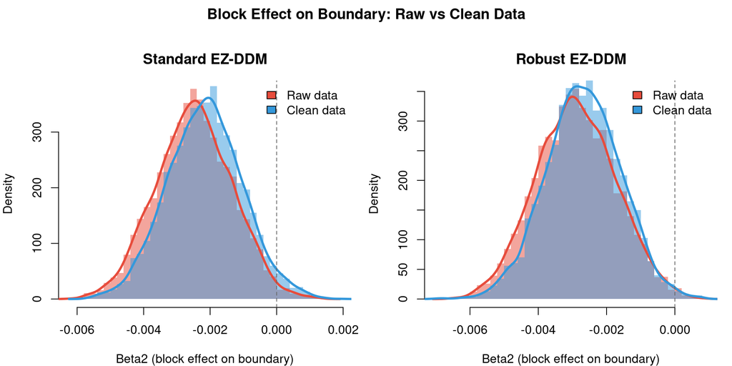

```r
nBreaks <- 40
raw.color <- "#E74C3C"
clean.color <- "#3498DB"

par(mfrow = c(1, 2), mai = c(0.8, 0.8, 0.6, 0.2), oma = c(0, 0, 2.5, 0))

# Standard EZ-DDM
xlim_std <- range(c(beta2_standard_raw, beta2_standard_clean))
hist(beta2_standard_raw, freq = FALSE, breaks = nBreaks, col = adjustcolor(raw.color, 0.5),
     border = NA, main = "Standard EZ-DDM", xlab = "Beta2 (block effect on boundary)",
     xlim = xlim_std)
hist(beta2_standard_clean, freq = FALSE, breaks = nBreaks, col = adjustcolor(clean.color, 0.5),
     border = NA, add = TRUE)
lines(density(beta2_standard_raw), lwd = 3, col = raw.color)
lines(density(beta2_standard_clean), lwd = 3, col = clean.color)
abline(v = 0, lty = 2, col = "gray40")
legend("topright", c("Raw data", "Clean data"), fill = c(raw.color, clean.color), bty = "n")

# Robust EZ-DDM
xlim_rob <- range(c(beta2_robust_raw, beta2_robust_clean))
hist(beta2_robust_raw, freq = FALSE, breaks = nBreaks, col = adjustcolor(raw.color, 0.5),
     border = NA, main = "Robust EZ-DDM", xlab = "Beta2 (block effect on boundary)",
     xlim = xlim_rob)
hist(beta2_robust_clean, freq = FALSE, breaks = nBreaks, col = adjustcolor(clean.color, 0.5),
     border = NA, add = TRUE)
lines(density(beta2_robust_raw), lwd = 3, col = raw.color)
lines(density(beta2_robust_clean), lwd = 3, col = clean.color)
abline(v = 0, lty = 2, col = "gray40")
legend("topright", c("Raw data", "Clean data"), fill = c(raw.color, clean.color), bty = "n")

mtext("Block Effect on Boundary: Raw vs Clean Data", outer = TRUE, line = 1, cex = 1.2, font = 2)
```

## Boundary Separation Across Blocks

```r
# Posterior samples for the predicted boundary separation (iterations x nBlocks x 2 modalities)
bound_pred_samples <- samples_robust_clean$BUGSoutput$sims.list$bound_pred

# Mean prediction and 95% CI of the prediction itself, varying continuously by block
bound_pred_mean  <- apply(bound_pred_samples, c(2, 3), mean)
bound_pred_lower <- apply(bound_pred_samples, c(2, 3), quantile, probs = 0.025)
bound_pred_upper <- apply(bound_pred_samples, c(2, 3), quantile, probs = 0.975)

# Posterior mean bound[i] for each participant-block cell
bound_recovered <- apply(samples_robust_clean$BUGSoutput$sims.list$bound, 2, mean)
plot_data <- summaries_clean
plot_data$bound_mean <- bound_recovered

# Aggregate across participants per block x modality: mean +/- 1.96*SE
agg_recovered <- aggregate(bound_mean ~ block + modality, data = plot_data,
                            FUN = function(x) c(mean = mean(x), se = sd(x) / sqrt(length(x))))
agg_recovered <- do.call(data.frame, agg_recovered)
names(agg_recovered) <- c("block", "modality", "mean", "se")
agg_recovered$lower <- agg_recovered$mean - 1.96 * agg_recovered$se
agg_recovered$upper <- agg_recovered$mean + 1.96 * agg_recovered$se
```

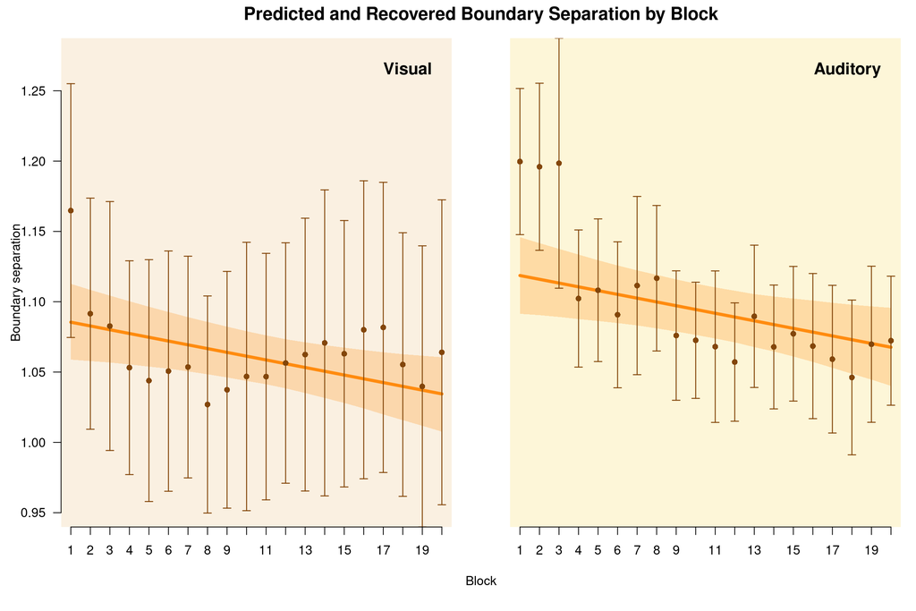

```r
vis.bckg <- "#faf0e1"
aud.bckg <- "#fdf6d8"
predicted.color <- "#FF8B0F"
ci.color <- adjustcolor("#FF8B0F", 0.25)
recovered.color <- "#83460A"

gap <- 3
blocks     <- 1:nB
x_visual   <- blocks
x_auditory <- blocks + nB + gap

vis_agg <- agg_recovered[agg_recovered$modality == 1, ]
aud_agg <- agg_recovered[agg_recovered$modality == 2, ]
vis_agg <- vis_agg[order(vis_agg$block), ]
aud_agg <- aud_agg[order(aud_agg$block), ]

ylim_range <- range(c(bound_pred_lower, bound_pred_upper,
                       agg_recovered$lower, agg_recovered$upper))
xlim_range <- c(min(x_visual) - 0.5, max(x_auditory) + 0.5)
y_lab_pos  <- ylim_range[2] - 0.05 * diff(ylim_range)

par(pty = "m", mfrow = c(1, 1), mai = c(1.1, 0.8, 0.5, 0.2), oma = c(0, 0, 0, 0))

plot(NULL, xlim = xlim_range, ylim = ylim_range, ann = FALSE, axes = FALSE,
     xaxs = "i", yaxs = "i")

polygon(c(min(x_visual) - 0.5, max(x_visual) + 0.5, max(x_visual) + 0.5, min(x_visual) - 0.5),
        c(ylim_range[1], ylim_range[1], ylim_range[2], ylim_range[2]),
        col = vis.bckg, border = NA)
polygon(c(min(x_auditory) - 0.5, max(x_auditory) + 0.5, max(x_auditory) + 0.5, min(x_auditory) - 0.5),
        c(ylim_range[1], ylim_range[1], ylim_range[2], ylim_range[2]),
        col = aud.bckg, border = NA)

polygon(c(x_visual, rev(x_visual)),
        c(bound_pred_lower[, 1], rev(bound_pred_upper[, 1])),
        col = ci.color, border = NA)
polygon(c(x_auditory, rev(x_auditory)),
        c(bound_pred_lower[, 2], rev(bound_pred_upper[, 2])),
        col = ci.color, border = NA)

lines(x_visual, bound_pred_mean[, 1], lwd = 4, col = predicted.color)
lines(x_auditory, bound_pred_mean[, 2], lwd = 4, col = predicted.color)

arrows(x_visual, vis_agg$lower, x_visual, vis_agg$upper,
       length = 0.05, angle = 90, code = 3, col = recovered.color, lwd = 1.2)
points(x_visual, vis_agg$mean, pch = 16, col = recovered.color, cex = 1)

arrows(x_auditory, aud_agg$lower, x_auditory, aud_agg$upper,
       length = 0.05, angle = 90, code = 3, col = recovered.color, lwd = 1.2)
points(x_auditory, aud_agg$mean, pch = 16, col = recovered.color, cex = 1)

axis(1, at = x_visual,   labels = blocks)
axis(1, at = x_auditory, labels = blocks)
axis(2, las = 2)
mtext("Boundary separation", 2, line = 2.5)
mtext("Block", 1, line = 3)

text(max(x_visual) - 0.5,   y_lab_pos, "Visual",   adj = c(1, 1), cex = 1.3, font = 2)
text(max(x_auditory) - 0.5, y_lab_pos, "Auditory", adj = c(1, 1), cex = 1.3, font = 2)

mtext("Predicted and Recovered Boundary Separation by Block", 3, line = 1, cex = 1.4, font = 2)
```

## Model Comparison: DIC

Last, we take a look at the DIC values for the different models.

```r
cat("STANDARD EZ-DDM:\n")
cat("  Raw data:   ", round(samples_standard_raw$BUGSoutput$DIC, 1), "\n")
cat("  Clean data: ", round(samples_standard_clean$BUGSoutput$DIC, 1), "\n\n")
cat("ROBUST EZ-DDM:\n")
cat("  Raw data:   ", round(samples_robust_raw$BUGSoutput$DIC, 1), "\n")
cat("  Clean data: ", round(samples_robust_clean$BUGSoutput$DIC, 1), "\n")
```

```
## STANDARD EZ-DDM:
```

```
##   Raw data:    -6777.5
```

```
##   Clean data:  -7192.8
```

```
## ROBUST EZ-DDM:
```

```
##   Raw data:    -7865.8
```

```
##   Clean data:  -8138.1
```

# Summary and Conclusions

## Recommendations

- **Use Robust EZ-DDM** when data cleaning procedures are uncertain or when outliers are expected
- The similarity of Robust estimates across raw/clean data can serve as a diagnostic: if results differ substantially, the data may have unusual contamination patterns
- Standard EZ-DDM remains appropriate for carefully curated, clean data where efficiency (lower posterior variance) is prioritized

# References

Chávez De la Peña, A. F., Shin, E., & Vandekerckhove, J. (2026). Robust Bayesian hypothesis testing with the EZ-DDM. *Behavior Research Methods*. https://doi.org/10.3758/s13428-026-02202-y

Ferrand, L., Méot, A., Spinelli, E., New, B., Pallier, C., Bonin, P., Dufau, S., Mathôt, S., & Grainger, J. (2018). MEGALEX: A megastudy of visual and auditory word recognition. *Behavior Research Methods, 50*(3), 1285-1307. https://doi.org/10.3758/s13428-017-0943-1